# Deconvoluting pathogen infection RNAi screens with gespeR

Fabian Schmich

This file contains step-by-step instructions on how to obtain the data and deconvolute phenotypes from pathogen infection screens, as shown in *gespeR: A statistical model for deconvoluting off-target-confounded RNA interference screens* (Schmich et al., 2015). For full compatibility, please download the development version of gespeR at: https://github.com/fschmich/gespeR

## Downloading data

### Phenotypic data

1. Go to https://pubchem.ncbi.nlm.nih.gov/assay/assay.cgi?aid=1117357&viewcode=X, replacing **X** with the viewcode provided (data is on hold until March 19, 2016).
2. At the top table, in the description field, click *View All Data*.
3. Scroll to the bottom of the page. Under *Result Exports* choose to save BioAssay as CSV file to /tmp/phenotypes.csv.
4. Download the mapping from PubChem to Vendor siRNA IDs from http://www.ncbi.nlm.nih.gov/pcsubstance/?term=%22InfectX+Consortium%22%5Bsourcename%5D. On the top right of the page, press *Send To* -> *File* -> *Format: ID Map* and save to /tmp/mapping.txt.

### Target relation matrices

1. Go to https://www1.ethz.ch/bsse/cbg/software/gespeR.
2. Download the following siRNA-to-gene target relation matrices
   - Qiagen libraries to /tmp/QIAGEN.rds
   - Dharmacon library to /tmp/DHARMACON.rds
   - Validation library to /tmp/VALIDATION.rds
3. Alternatively, from within R, type

```r
sapply(c("QIAGEN", "DHARMACON", "VALIDATION"), function(x) {
  download.file(url = sprintf("http://n.ethz.ch/~fschmich/gespeR/%s.rds", x),
                destfile = sprintf("/tmp/%s.rds", x), quiet = FALSE, mode = "wb")
})
```

## Preprocessing data

### Target relation matrices

```r
require(Matrix)
require(gespeR)
# Construct TargetRelations objects for each library
Q <- TargetRelations("/tmp/QIAGEN.rds")
show(Q)
```

```
## 91003 x 27240 siRNA-to-gene relations.
## 10 x 5 sparse Matrix of class "dgCMatrix"
##            1    2 3          9 10
## SI00000007 . 0.75 . .           .
## SI00000035 . .    . .           .
## SI00000063 . .    . 0.10992427  .
## SI00000070 . .    . .           .
## SI00000077 . .    . .           .
## SI00000084 . .    . .           .
## SI00000105 . .    . .           .
## SI00000112 . .    . 0.09310967  .
## SI00000119 . .    . .           .
## SI00000133 . .    . .           .
## ...
```

### Phenotypic data

```r
require(dplyr)
require(reshape2)
require(gespeR)
# Read phenotypes
phenotypes <- read.delim("/tmp/phenotypes.csv",
                         sep = ",", stringsAsFactors = FALSE) %>%
  tbl_df() %>%
  select(SID, GeneID = NCBI.Gene.ID, siRNASet = SIRNA_SET, contains("Infectivity")) %>%
  melt(id.vars = c("SID", "siRNASet", "GeneID")) %>%
  tbl_df() %>%
  select(SID = SID, GeneID, siRNASet, Pathogen = variable, Phenotype = value) %>%
  mutate(Pathogen = gsub("Infectivity_", "", Pathogen),
         SID = as.character(SID)) %>%
  filter(!is.na(Phenotype)) %>% # Artifact of how data is deposited in Pubchem
  arrange(SID)
head(phenotypes)
```

```
## Source: local data frame [6 x 5]
##
##         SID GeneID siRNASet   Pathogen Phenotype
## 1 249376050     53        5 Salmonella  0.354975
## 2 249376051     53        5 Salmonella  1.588140
## 3 249376052     53        5 Salmonella  2.014610
## 4 249376053    373        5 Salmonella -1.078850
## 5 249376054    379        5 Salmonella -1.452680
## 6 249376055   9275        5 Salmonella  0.342689
```

```r
# Read ID mapping between SIDs and Vendor IDs
map <- read.delim("/tmp/mapping.txt", header = FALSE, stringsAsFactors = FALSE)
map <- map[seq(2, nrow(map), by = 2),]
map <- data.frame(t(sapply(map, function(x) {
  unlist(strsplit(x, split = "SID: | InfectX Consortium: "))[2:3]
})), stringsAsFactors = FALSE) %>% tbl_df()
rownames(map) <- NULL
colnames(map) <- c("SID", "VendorID")

# Map IDs
phenotypes <- left_join(phenotypes, map, by = "SID") %>%
  tbl_df() %>%
  select(SID, VendorID, siRNASet, GeneID, Pathogen, Phenotype)
head(phenotypes)
```

```
## Source: local data frame [6 x 6]
##
##         SID VendorID siRNASet GeneID   Pathogen Phenotype
## 1 249376050    10031        5     53 Salmonella  0.354975
## 2 249376051    10122        5     53 Salmonella  1.588140
## 3 249376052    10210        5     53 Salmonella  2.014610
## 4 249376053    10235        5    373 Salmonella -1.078850
## 5 249376054    10240        5    379 Salmonella -1.452680
## 6 249376055    10268        5   9275 Salmonella  0.342689
```

```r
# Construct Phenotypes objects for each (Qiagen) library + pathogen combination
obs.ssp <- obs.gsp <- list()
phenotypes <- split(phenotypes, phenotypes$Pathogen)
for (pathogen in names(phenotypes)) {
  obs.ssp[[pathogen]] <- obs.gsp[[pathogen]] <- list()
  for (s in 1:4) {
    spl <- filter(phenotypes[[pathogen]], siRNASet == s, VendorID %in% Q@siRNAs)
    obs.ssp[[pathogen]][[s]] <- Phenotypes(phenotypes = Matrix(spl$Phenotype),
                                           ids = spl$VendorID,
                                           pnames = c("Infectivity"),
                                           type = "SSP")
    spl.noNA <- filter(spl, !is.na(GeneID)) %>%
      group_by(GeneID) %>%
      summarise(Phenotype = mean(Phenotype, na.rm = TRUE)) %>%
      filter(!is.nan(Phenotype))
    # We need gene-based Phenotypes objects for concordance evaluation
    obs.gsp[[pathogen]][[s]] <- Phenotypes(phenotypes = Matrix(spl.noNA$Phenotype),
                                           ids = as.character(spl.noNA$GeneID),
                                           pnames = c("Infectivity"),
                                           type = "GSP")
  }
}
show(obs.ssp$Bartonella[[1]])
```

```
## 20087 SSP Phenotypes
##
## Source: local data frame [20,087 x 2]
##
##            ID Infectivity
## 1  SI00000035  -1.2441600
## 2  SI00000077   2.0732300
## 3  SI00000112  -1.0704600
## 4  SI00000168  -1.7540600
## 5  SI00000266  -0.8546760
## 6  SI00000399  -0.4619630
## 7  SI00000420   1.3742000
## 8  SI00000476   0.4220430
## 9  SI00000518  -1.7471500
## 10 SI00000567   0.0507219
## ..        ...         ...
```

## Fitting gespeR models

```r
require(gespeR)
# Fit gespeR models
ans.cv <- list()
for (pathogen in c("Bartonella", "Brucella", "Salmonella")) {
  ans.cv[[pathogen]] <- list()
  for (s in 1:4) {
    cat(sprintf("set: %d, pathogen: %s\n", s, pathogen))
    ges <- gespeR(phenotypes = obs.ssp[[pathogen]][[s]],
                                      target.relations = Q,
                                      mode = "cv",
                                      alpha = 0.5,
                                      ncores = 1)
    ans.cv[[pathogen]][[s]] <- unloadValues(ges, writeValues = FALSE)
  }
}
```

```r
# Obtain gene-specific phenotypes (GSPs)
ges.gsp <- lapply(ans.cv, function(x) {
  lapply(x, gsp)
})
```

## Concordance evaluation

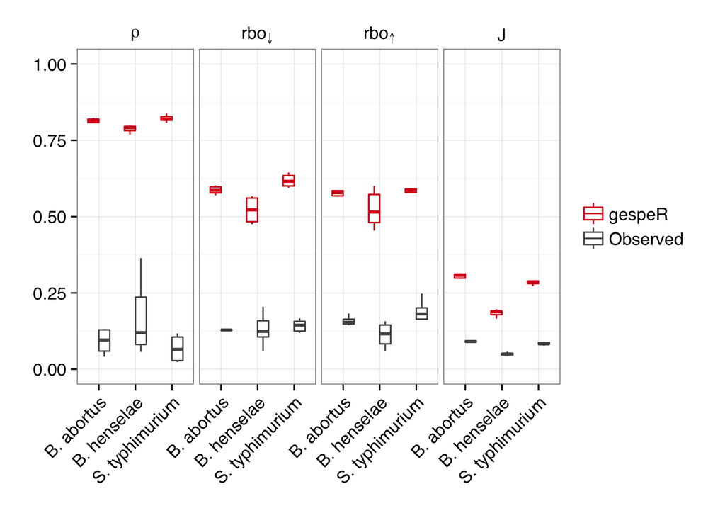

```r
require(gespeR)
require(ggplot2)
# Function computes concordance between all pairs of phenotypes. Measures used
# are Spearman's correlation, rank-biased overlap and the Jaccard index.
# Observed phenotypes are cut to the same length as gespeR GSPs, respecting the
# proportion of negative and positive phenotypes, in order to guarantee fair
# comparison.
get.conc <- function(phen, cut = NULL) {
  min.overlap = 10
  rbo.k = 1000
  rbo.p = 1-1e-3
  rbo.mid <- 0
  cor.method = "spearman"
  uneven.lengths = TRUE
  if (!is.null(cut)) { # cut longer ranked lists to gespeR's lengths
    lapply(names(phen), function(x) {
      l <- lapply(cut[[x]], function(z) {
        ans <- as.data.frame(z)
        list(pos = length(which(ans$Infectivity > 0)), neg = length(which(ans$Infectivity < 0)))
      })
      phencut <- lapply(phen[[x]], function(y) {
          as.data.frame(y) %>%
            tbl_df() %>%
            mutate(ID = as.character(ID)) %>%
            filter(!is.na(Infectivity)) %>%
            arrange(desc(Infectivity))
      })
      for (lib in 1:length(l)) {
        len <- l[[lib]]
        a <- nrow(phencut[[lib]]) - len$neg + 1
        b <- nrow(phencut[[lib]])
        phencut[[lib]] <- phencut[[lib]][c(1:len$pos, a:b),]
        phencut[[lib]] <- Phenotypes(phenotypes = Matrix(phencut[[lib]]$Infectivity),
                                     ids = phencut[[lib]]$ID,
                                     pnames = c("Infectivity"),
                                     type = "SSP")
      }
      concordance(phencut,
                  min.overlap = min.overlap,
                  rbo.k = rbo.k,
                  rbo.p = rbo.p,
                  cor.method = cor.method,
                  rbo.mid = rbo.mid,
                  uneven.lengths = uneven.lengths) %>%
        data.frame %>%
        select(-lisect) %>%
        melt(id.vars = c("test.pair", "phen")) %>%
        mutate(Method = "SSP", Pathogen = x) %>%
        select(-test.pair, Method, Pathogen, Measure = variable, value) %>%
        tbl_df()
    }) %>% do.call("rbind", .)
  } else {
    lapply(names(phen), function(x) {
      concordance(phen[[x]],
                  min.overlap = min.overlap,
                  rbo.k = rbo.k,
                  rbo.p = rbo.p,
                  cor.method = cor.method,
                  rbo.mid = rbo.mid,
                  uneven.lengths = uneven.lengths) %>%
        data.frame %>%
        select(-lisect) %>%
        melt(id.vars = c("test.pair", "phen")) %>%
        mutate(Method = "gespeR", Pathogen = x) %>%
        select(-test.pair, Method, Pathogen, Measure = variable, value) %>%
        tbl_df()
    }) %>% do.call("rbind", .)
  }
}
# Computation of concordance for gespeR GSPs and observed phenotypes
conc.gespeR <- get.conc(ges.gsp)
conc.obs <- get.conc(obs.gsp, cut = ges.gsp)

# Visualisation of concordance measures
dat <- rbind(conc.gespeR, conc.obs) %>% tbl_df() %>%
  mutate(Pathogen = factor(Pathogen, levels = c("Brucella", "Bartonella", "Salmonella"),
                           labels = c("B. abortus", "B. henselae", "S. typhimurium")),
         Method = factor(Method, levels = c("gespeR", "SSP"),
                         labels = c("gespeR", "Observed")))
dat$Measure <- factor(dat$Measure,
                      levels = c("cor", "rbo.top", "rbo.bottom", "jaccard"),
                      labels = c(expression(rho), expression(rbo["" %down% ""]),
                                 expression(rbo["" %up% ""]), expression("J")))
ggplot(data = dat, aes(x = Pathogen, y = value, colour = Method)) +
      geom_boxplot(outlier.size = 0, width = 0.8) +
      facet_grid(. ~ Measure, labeller = label_parsed) +
      xlab("") + ylab("") +
      scale_colour_manual("", values = c("#d7191c", "#525252"), drop = FALSE) +
      ylim(c(0, 1)) +
      theme_bw(base_size = 12, base_family = "Helvetica") +
      theme(axis.text = element_text(size = rel(1.0)),
            axis.title = element_text(size = rel(1.0), face = "bold"),
            strip.text = element_text(size = rel(1.0), face = "bold"),
            axis.ticks = element_line(colour = "black"),
            legend.key = element_rect(colour = NA),
            legend.text = element_text(size = rel(1.0)),
            legend.title = element_text(size = rel(1.0), face = "bold"),
            panel.background = element_rect(fill = "white", colour = NA),
            panel.border = element_rect(fill = NA, colour = "grey50"),
            panel.grid.major = element_line(colour = "grey90", size = 0.2),
            panel.grid.minor = element_line(colour = "grey98", size = 0.5),
            strip.background = element_blank(),
            axis.text.x = element_text(angle = 45, hjust = 1))
```